# Predicting movie ratings with Text Mining and Supervised algorithms

Francesco Nicolí

2023-09-24

# Introduction: predicting movie ratings

The purpose of this project is to build a set of ML models that aim to predict a **movie’s average rating** based on the text information contained in the comments written by the users. In order to do so, we are going to use a set of Text Mining, dimensionality reduction and prediction techniques that best fit the purpose at hand.

The dataset we used to train and test the model is the **Internet Movie Database (IMDb)**, a dataset containing a vast amount of variables associated with each movie. However, for our analysis, we are going to use a subset of the variables, including the information about the **genre**, the **tags**, and the **average rating** for each movie.

The project is divided in two parts. The **first part** goes through the data preprocessing, the Text Mining analysis and the dimensionality reduction, performed through PCA (Principal Component Analysis). The **second part** is about the algorithm training, model selection and final prediction. In this part, we are going to tune an SVM and an Artificial Neural Network and test which performs better in this context.

# Part 1: Text Mining Analysis

## Data Preprocessing

Before taking on the Text Mining Analysis we intend to perform on the Movie Data, we need to preprocess the **tags dataset**: the one containing the tags from each user regarding each movie. The preprocessing consists of removing duplicates, merging the tags in one line and removing special characters.

```r
# Reading tags.csv file and keeping "movieId" and "tags" columns
tags <- fread("C:/Users/optif/OneDrive/Desktop/academics/applied_statistics/Francesco_repository_1/data/tags-file2.csv")
tags <- tags %>%
  select(movieId, tag)

dim(tags) # print dimensions
```

```
## [1] 1093360       2
```

```r
# Removing duplicated movieTags and aggregating tags
tb <- tags %>%
  group_by(movieId) %>%
  summarise(tag = paste(unlist(list(as.character(tag))), collapse = " "))

dim(tb) # print dimensions
```

```
## [1] 45251     2
```

```r
# Filter for tags with at least 100 words
tb <- tb %>%
  filter(as.numeric(sapply(strsplit(tag, " "), length)) > 100)

dim(tb) # print dimensions
```

```
## [1] 2918    2
```

```r
# Removing special characters from tags
tb <- tb %>%
  mutate(tag = gsub("[[:punct:]]", "", tag))

dim(tb) # print dimensions
```

```
## [1] 2918    2
```

Our task is to build a **Document Term Matrix** containing individual movies as documents and terms/words occurring in tags as columns. Furthermore, we decided to create **bi_grams** in our dataset. Hence, we have to be careful as our matrix will become sparse very quickly.

```r
# Tags corpus
corp_tags <- VCorpus(VectorSource(tb$tag))
inspect(corp_tags[1:5]) # inspecting first 5 rows of corpus
```

```
## <<VCorpus>>
## Metadata:  corpus specific: 0, document level (indexed): 0
## Content:  documents: 5
##
## [[1]]
## <<PlainTextDocument>>
## Metadata:  7
## Content:  chars: 6244
##
## [[2]]
## <<PlainTextDocument>>
## Metadata:  7
## Content:  chars: 2070
##
## [[3]]
## <<PlainTextDocument>>
## Metadata:  7
## Content:  chars: 6945
##
## [[4]]
## <<PlainTextDocument>>
## Metadata:  7
## Content:  chars: 894
##
## [[5]]
## <<PlainTextDocument>>
## Metadata:  7
## Content:  chars: 1516
```

```r
# Creating the BigramTokenizer function for creating Bi-grams in the DTM
BigramTokenizer <- function(x){
  NGramTokenizer(x, Weka_control(min=1, max=2))
}

corp_tags <- tm_map(corp_tags, stripWhitespace)

# Converting corp_tags into DocumentTermMatrix object
DTM_tags_DF_IDF <- DocumentTermMatrix(corp_tags, control = list(
            tolower = TRUE, # Converts to lowercase
            removeNumbers = TRUE, # Removes numbers
            stopwords = TRUE, # Removes common words with almost 0 info value
            removePunctuation = TRUE, # Even if we did it previously
            stripWhitespace = TRUE, # Removes white space characters
            tokenize = BigramTokenizer, # Setting Tokenizer parameter
            weighting = weightTfIdf)) # Setting weighting to Inverse Document
                                      # Frequency

dim(DTM_tags_DF_IDF) # print dimensions of DTM_tags_DF_IDF
```

```
## [1]   2918 338118
```

```r
inspect(DTM_tags_DF_IDF[,c(1:5)]) # inspecting content of first 5
```

```
## <<DocumentTermMatrix (documents: 2918, terms: 5)>>
## Non-/sparse entries: 7/14583
## Sparsity           : 100%
## Maximal term length: 10
## Weighting          : term frequency - inverse document frequency (normalized) (tf-idf)
## Sample             :
##       Terms
## Docs     aardman       aaron  abduction   abortion      about
##   1    0.0000000 0.000000000 0.00000000 0.00000000 0.00000000
##   1590 0.0240811 0.000000000 0.00000000 0.00000000 0.00000000
##   1829 0.0000000 0.000000000 0.01112151 0.00000000 0.00000000
##   2    0.0000000 0.000000000 0.00000000 0.00000000 0.00000000
##   2175 0.0000000 0.003279089 0.00000000 0.00000000 0.00000000
##   2178 0.0000000 0.000000000 0.00000000 0.00000000 0.02438721
##   2210 0.0000000 0.041015709 0.00000000 0.00000000 0.00000000
##   3    0.0000000 0.000000000 0.00000000 0.00000000 0.00000000
##   600  0.0000000 0.008768376 0.00000000 0.00000000 0.00000000
##   810  0.0000000 0.000000000 0.00000000 0.02339586 0.00000000
```

```r
                                            # columns of DTM_tags_DF_IDF
```

In this first step of the Text Mining phase, we decided to create a Document-Term Matrix by converting all characters to *lowercase* characters, removing all *numbers*, removing *common words* (since those words don’t provide informational value), removing *punctuation* and stripping additional white spaces in the strings. We also decided to add **bi-grams** to the DTM in order to include an ad-hoc analysis of the many two-word tags coming in the dataset.

In addition, we created the DTM object that stores the number of occurrences computed using the **Term Frequency - Inverse Document Frequency** adjustment rule. This method allows us to take into account both the frequency of terms in a tag and the frequency of tags containing that term, thus identifying documents with frequent occurrences of rare terms.

In the next step, we address sparsity for both single words and bi-grams.

```r
# Removing sparse tokens from the DTM_tags_DF_IDF
DTM_tags_TF_IDF2 <- removeSparseTerms(DTM_tags_DF_IDF, 0.996) # 99.6% maximum
                                                              # sparsity

# Checking for dimensions of new DTM
dim(DTM_tags_TF_IDF2)
```

```
## [1] 2918 6060
```

```r
# Printing the first five terms of the new DTM
inspect(DTM_tags_TF_IDF2[,c(1:5)])
```

```
## <<DocumentTermMatrix (documents: 2918, terms: 5)>>
## Non-/sparse entries: 175/14415
## Sparsity           : 99%
## Maximal term length: 10
## Weighting          : term frequency - inverse document frequency (normalized) (tf-idf)
## Sample             :
##       Terms
## Docs      academy     action  adventure        afi  animation
##   1722 0.00000000 0.06862188          0 0.00000000          0
##   2542 0.03433334 0.00000000          0 0.00000000          0
##   2566 0.04056095 0.00000000          0 0.00000000          0
##   2583 0.13061370 0.00000000          0 0.00000000          0
##   2596 0.03577109 0.00000000          0 0.00000000          0
##   2604 0.10383472 0.00000000          0 0.00000000          0
##   335  0.00000000 0.00000000          0 0.03896168          0
##   467  0.00000000 0.04389245          0 0.00000000          0
##   868  0.00000000 0.00000000          0 0.03593286          0
##   900  0.00000000 0.00000000          0 0.03580633          0
```

```r
# Return the number of bi-grams in the DTM_tags_TF_IDF2
sum(as.numeric(sapply(strsplit(trimws(DTM_tags_TF_IDF2$dimnames$Terms), " "),
                      length)) > 1)
```

```
## [1] 2839
```

In this last step of the Text Mining section, we filtered for terms with a *sparsity* less or equal to **99.6%**. This value seems reasonable since 0.4% of the tags is around 12 tags: we definitely do not want to include tokens appearing in less than 12 tags but tokens that appear in more than 12 tags can turn out to be useful for the analysis. In conclusion, we compute the number of bi-grams present in our Document Term Matrix: **2839** bi-grams out of 6060 words filtered.

# Principle Component Analysis

Now that we have a DTM, we can use it in an **unsupervised machine learning** **algorithm** that can reduce the dimensionality of the data. Specifically we have terms/words that describe each movie, however likely we have way too many columns and should only use a **reduced amount of columns** in our further analysis. For example we may wish to run a classification algorithm such as an SVM as a final step in order to be able to create a model that can predict a movie’s rating based on some features, including the features produced as a result of running the PCA.

```r
# Converting the DTM object into a tibble first
m <- as.matrix(DTM_tags_TF_IDF2)
DTM_tags_tbl <- as_tibble(m)

# Standardizing the dataset
DTM_pca <- scale(DTM_tags_tbl, center = TRUE, scale = TRUE)

# Running PCA on DTM_pca
tags_pca <- prcomp(DTM_pca, center = FALSE, scale. = FALSE)
```

After *standardizing* the dataset and running the *PCA* on it, we are ready to perform the **Analysis of the Variance**.

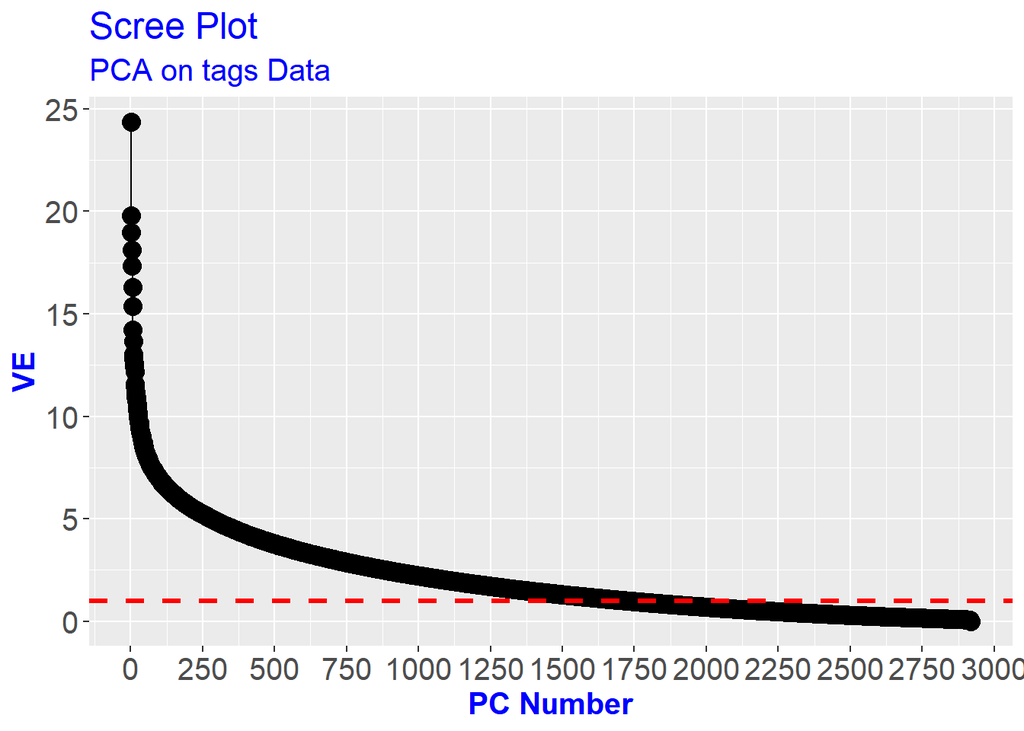

```r
# "Variance Explained" as vector of the SDev^2 explained by each PC
VE <- tags_pca$sdev^2

# "Percentage of Variance Explained" as proportion of total variance explained
# by each PC
PVE <- VE/sum(VE)*100

# Cumulative Percentage of Variance Explained
CPVE <- cumsum(PVE)

# Creating Data frame object containing data about Variance Explained by each PC
df <- data.frame(PC = c(1:length(tags_pca$sdev)),
                 var_explained = VE,
                 cum_sum_PVE = CPVE)

# Building Scree Plot of the Variance Explained
df %>%
  ggplot(aes(x = PC, y = var_explained)) +
  geom_point(size = 4) +
  geom_line() +
  scale_x_continuous(breaks = seq(0,3000,250)) +
  geom_hline(yintercept = 1, linetype = "dashed", color = "red", size = 1.2) +
  labs(x = "PC Number", y = "VE",
       title = "Scree Plot",
       subtitle = "PCA on tags Data") +
  theme(axis.text = element_text(size = 15),
        axis.title = element_text(size = 15, face = "bold", color = "blue"),
        plot.title = element_text(size = 18, color = "blue"),
        plot.subtitle = element_text(size = 15, color = "blue")
  )
```

Since it is difficult to pinpoint where the elbow occurs exactly, we are going to build another Scree Plot showing the Variance Explained by all the PCs from the 1st to the 50th.

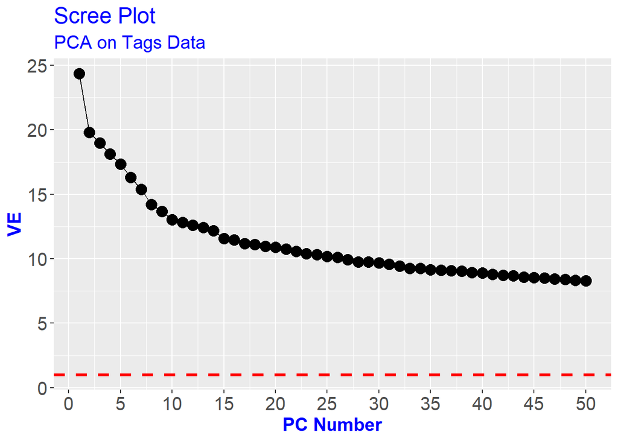

```r
# Building Scree Plot of the Variance Explained for the first 50 PCs
df[c(1:50),] %>%
  ggplot(aes(x = PC, y = var_explained)) +
  geom_point(size = 4) +
  geom_line() +
  scale_x_continuous(breaks = seq(0,50,5)) +
  geom_hline(yintercept = 1, linetype = "dashed", color = "red", size = 1.2) +
  labs(x = "PC Number", y = "VE",
       title = "Scree Plot",
       subtitle = "PCA on Tags Data") +
  theme(axis.text = element_text(size = 15),
        axis.title = element_text(size = 15, face = "bold", color = "blue"),
        plot.title = element_text(size = 18, color = "blue"),
        plot.subtitle = element_text(size = 15, color = "blue")
  )
```

As we can see by the Scree Plot, the elbow occurs at the 10th PC. In fact, after this PC, the amount of variance explained tends to flatten out. Hence, we are going to keep **10 PCs** for our further analysis.

```r
# Dataset containing the number of PCs we decided to keep (10)
final_dataset <- tags_pca$x[,c(1:10)]
dim(final_dataset) # Print dimensions
```

```
## [1] 2918   10
```

```r
# Adding movieId column back to the dataset
features_pca <- data.frame(tb$movieId, final_dataset) # Adding movieId column
```

# Part 2: SVM and Neural Network fit

## Data Preprocessing

Before fitting the ML algos we intend to (Support Vector Machine & Artificial Neural Network), we need to **preprocess** our data to get the final dataset we are going to use in our analysis. We want to use the **Principal Components** we kept from Part 1 as the first **10 variables**. In addition, we want to create **20 dummy variables**: those variables are gonna be binary variables and their value is gonna depend on whether the movie belongs to a certain **genre** or not. Finally, we are gonna add the **average rating** for each movie (the 31st variable in our dataset), which is our **output variable** (the one we are gonna try to predict).

Hence, we are going to import the dataset containing the average rating for each movie (*ratings*) and the dataset containing the name and genre of each movie (*movies*). Afterwards, we are going to **join** the latter two datasets with the one containing the Principal Components.

```r
# Loading ratings dataset
ratings <- fread("C:/Users/optif/OneDrive/Desktop/academics/applied_statistics/Francesco_repository_1/data/ratings_actual.csv")

# Loading movies dataset
movies <- fread("C:/Users/optif/OneDrive/Desktop/academics/applied_statistics/Francesco_repository_1/data/movies_actual.csv")

# Joining ratings and movies data
movies_ratings <- left_join(ratings, movies, by = c("movieId"="movieId"))

# Joining movies_ratings and features_pca dataset
final_dataset <- left_join(features_pca, movies_ratings,
                           by = c("tb.movieId"="movieId"))

# Creating vector with all genres in dataset
genres_vec <- unique(unlist(strsplit(movies$genres, split = "\\|")))

# Adding dummy variables to final_dataset for each genre
for(i in genres_vec){
  final_dataset <- data.frame(final_dataset,
                              as.numeric(str_detect(final_dataset$genres, i)))
}

# Fixing column names in the final_dataset
colnames(final_dataset)[15:34] <- genres_vec

# Dropping columns we do not need
final_dataset <- final_dataset %>%
  select(-genres, -title, -tb.movieId)
```

## First Task: Support Vector Machine

```r
# Converting the column with average rating into a binary column
final_dataset_svm <- final_dataset %>%
  mutate(avg_rating = ifelse(avg_rating>=3.75, 1, 0))

# Split the data into training and testing set
set.seed(1234)
train_test <- initial_split(final_dataset_svm, prop = 0.8)
data_svm_train <- training(train_test)
data_svm_test <- testing(train_test)
```

Now we can try different types of SVM: Linear, Radial and Poly.

```r
# Creating grid containing hyper parameters to tune
grid <- expand.grid(sigma = c(0.016, 0.017, 0.018, 0.019, 0.020),
                    C = c(1,2,3,4,5,6,7,8,9,10))

# Training Radial SVM
SVM_Radial <- caret::train(
  as.factor(avg_rating) ~ .,
  data = data_svm_train,
  method = "svmRadial", # Radial kernel
  preProcess = c("center", "scale"),  # center & scale the data
  trControl = trainControl(method = "cv", number = 10), #cross-validation (10-fold)
  tuneGrid = grid # grid created above
)

# Printing details about the Radial SVM tuned
print(SVM_Radial)
```

```
## Support Vector Machines with Radial Basis Function Kernel
##
## 2334 samples
##   30 predictor
##    2 classes: '0', '1'
##
## Pre-processing: centered (30), scaled (30)
## Resampling: Cross-Validated (10 fold)
## Summary of sample sizes: 2101, 2101, 2100, 2101, 2101, 2100, ...
## Resampling results across tuning parameters:
##
##   sigma  C   Accuracy   Kappa
##   0.016   1  0.7866293  0.4458755
##   0.016   2  0.7900572  0.4621210
##   0.016   3  0.7934944  0.4786689
##   0.016   4  0.7973424  0.4914589
##   0.016   5  0.7939107  0.4859161
##   0.016   6  0.7952019  0.4914145
##   0.016   7  0.7939199  0.4880624
##   0.016   8  0.7922086  0.4841998
##   0.016   9  0.7904956  0.4820212
##   0.016  10  0.7904864  0.4816381
##   0.017   1  0.7853435  0.4422659
##   0.017   2  0.7909119  0.4659548
##   0.017   3  0.7926305  0.4769192
##   0.017   4  0.7947709  0.4862102
##   0.017   5  0.7951964  0.4896928
##   0.017   6  0.7939181  0.4880305
##   0.017   7  0.7930634  0.4868257
##   0.017   8  0.7922086  0.4861444
##   0.017   9  0.7892025  0.4789674
##   0.017  10  0.7891989  0.4798098
##   0.018   1  0.7862037  0.4453683
##   0.018   2  0.7896317  0.4629836
##   0.018   3  0.7960603  0.4866319
##   0.018   4  0.7939125  0.4845284
##   0.018   5  0.7939162  0.4880343
##   0.018   6  0.7934889  0.4869092
##   0.018   7  0.7939181  0.4893251
##   0.018   8  0.7904882  0.4819728
```

[output cut: 10 more lines]

```
##   0.019   9  0.7900536  0.4827206
##   0.019  10  0.7891989  0.4817521
##   0.020   1  0.7883423  0.4520961
##   0.020   2  0.7900609  0.4666415
##   0.020   3  0.7947691  0.4836943
##   0.020   4  0.7943417  0.4881234
##   0.020   5  0.7926305  0.4843191
##   0.020   6  0.7939162  0.4885252
##   0.020   7  0.7900591  0.4807083
##   0.020   8  0.7921995  0.4881119
##   0.020   9  0.7896262  0.4825653
##   0.020  10  0.7917703  0.4892237
##
## Accuracy was used to select the optimal model using the largest value.
## The final values used for the model were sigma = 0.016 and C = 4.
```

```r
# Display training accuracy metrics
confusionMatrix(SVM_Radial)
```

```
## Cross-Validated (10 fold) Confusion Matrix
##
## (entries are percentual average cell counts across resamples)
##
##           Reference
## Prediction    0    1
##          0 62.8 14.4
##          1  5.8 17.0
##
##  Accuracy (average) : 0.7973
```

```r
# Model validation on the test set
Radial_test_validation <- predict(SVM_Radial, data_svm_test)
confusionMatrix(data = Radial_test_validation, as.factor(data_svm_test$avg_rating))
```

```
## Confusion Matrix and Statistics
##
##           Reference
## Prediction   0   1
##          0 380  78
##          1  29  97
##
##                Accuracy : 0.8168
##                  95% CI : (0.783, 0.8473)
##     No Information Rate : 0.7003
##     P-Value [Acc > NIR] : 8.822e-11
##
##                   Kappa : 0.5255
##
##  Mcnemar's Test P-Value : 3.478e-06
##
##             Sensitivity : 0.9291
##             Specificity : 0.5543
##          Pos Pred Value : 0.8297
##          Neg Pred Value : 0.7698
##              Prevalence : 0.7003
##          Detection Rate : 0.6507
##    Detection Prevalence : 0.7842
##       Balanced Accuracy : 0.7417
##
##        'Positive' Class : 0
##
```

```r
# Training Poly SVM
SVM_Poly <- caret::train(
  as.factor(avg_rating) ~ .,
  data = data_svm_train,
  method = "svmPoly",
  trControl = trainControl(method = "cv", number = 10),
  preProcess = c("center","scale"),
  tuneLength = 4) # Parameter set to tune the 4 default values for the 3
                  # hyper parameters: degree, scale and C

# Print SVM_Poly details
print(SVM_Poly)
```

```
## Support Vector Machines with Polynomial Kernel
##
## 2334 samples
##   30 predictor
##    2 classes: '0', '1'
##
## Pre-processing: centered (30), scaled (30)
## Resampling: Cross-Validated (10 fold)
## Summary of sample sizes: 2101, 2100, 2100, 2101, 2100, 2101, ...
## Resampling results across tuning parameters:
##
##   degree  scale  C     Accuracy   Kappa
##   1       0.001  0.25  0.6872363  0.005615349
##   1       0.001  0.50  0.7043652  0.082087933
##   1       0.001  1.00  0.7253586  0.176197398
```

[output cut: 48 more lines]

```r
# Display training accuracy metrics
confusionMatrix(SVM_Poly)
```

```
## Cross-Validated (10 fold) Confusion Matrix
##
## (entries are percentual average cell counts across resamples)
##
##           Reference
## Prediction    0    1
##          0 62.4 14.7
##          1  6.2 16.7
##
##  Accuracy (average) : 0.7909
```

```r
# Model validation on the test set
Poly_test_validation <- predict(SVM_Poly, data_svm_test)
confusionMatrix(data = Poly_test_validation, as.factor(data_svm_test$avg_rating))
```

```
## Confusion Matrix and Statistics
##
##           Reference
## Prediction   0   1
##          0 380  81
##          1  29  94
##
##                Accuracy : 0.8116
##                  95% CI : (0.7775, 0.8426)
##     No Information Rate : 0.7003
##     P-Value [Acc > NIR] : 5.973e-10
##
##                   Kappa : 0.5096
##
##  Mcnemar's Test P-Value : 1.158e-06
##
##             Sensitivity : 0.9291
##             Specificity : 0.5371
##          Pos Pred Value : 0.8243
##          Neg Pred Value : 0.7642
##              Prevalence : 0.7003
##          Detection Rate : 0.6507
##    Detection Prevalence : 0.7894
##       Balanced Accuracy : 0.7331
##
##        'Positive' Class : 0
##
```

```r
# We are going to tune the only hyper parameter we have in the Linear SVM
# semi-automatically: by building a for loop testing for the values we want
# We first create a vector where to add the values of the Accuracy obtained
# at each step
Accuracy <- c()

# Here we build the for-loop
for(i in 1:10){
  SMV_Linear <- svm(as.factor(avg_rating) ~ .,
                    data = data_svm_train,
                    kernel = "linear",
                    cost = i,
                    scale = TRUE) # We choose to standardize the data

  # Test performance on out-of-sample data
  Linear_test_validation <- predict(SMV_Linear, data_svm_test)
  Lin_matrix <- confusionMatrix(data = Linear_test_validation,
                                as.factor(data_svm_test$avg_rating))

  # Add the Accuracy obtained to the Accuracy list
  Accuracy <- c(Accuracy, Lin_matrix$overall[1])

}

# Printing the values of Accuracy together with Cost values
Accuracy_dataset <- data.frame(seq(1,10,1), Accuracy)
Accuracy_dataset
```

```
##    seq.1..10..1.  Accuracy
## 1              1 0.8030822
## 2              2 0.8047945
## 3              3 0.8047945
## 4              4 0.8047945
## 5              5 0.8047945
## 6              6 0.8047945
## 7              7 0.8047945
## 8              8 0.8047945
## 9              9 0.8047945
## 10            10 0.8047945
```

As we can see by the dataset reporting the accuracy of the Linear SVM for the different values of the **cost**, the best accuracy is achieved with a Cost higher or equal to **2**: the model performs better for a **higher penalization** of the *margin violations*. It is possible to see that the accuracy is the same for any value of the cost that is at least equal to 2: **80.48%**. It is important to highlight that the accuracy measured is **out-of-sample**. Based on the data, the Linear SVM is the worst performing among all the SVM models built.

As we could see in all the three models built, though, *over fitting* is not an issue: besides measuring accuracy in-sample, we also measured accuracy out-of-sample and this actually turned out to be higher than the in-sample one. In addition, the hyper parameters were selected using the 10-fold cross validation procedure. Hence, the selection was performed taking into account the **out-of-sample performance** reported at each iteration.

Now, we will compare the results obtained with another classifier algorithm, to test the **relative effectiveness** of our SVM. The algorithm we are going to use to compare our results is the **logistic regression**.

```r
# Training the Logistic model
logistic <- glm(avg_rating ~ .,
                family="binomial",
                data_svm_train)

# Printing summary of logistic
summary(logistic)
```

```
##
## Call:
## glm(formula = avg_rating ~ ., family = "binomial", data = data_svm_train)
##
## Deviance Residuals:
##     Min       1Q   Median       3Q      Max
## -3.1429  -0.6794  -0.4055   0.5468   2.8963
##
## Coefficients:
##                      Estimate Std. Error z value Pr(>|z|)
## (Intercept)          -0.57315    0.17888  -3.204 0.001354 **
## PC1                   0.23361    0.02068  11.295  < 2e-16 ***
## PC2                   0.03080    0.01923   1.602 0.109178
## PC3                  -0.10454    0.04645  -2.251 0.024409 *
## PC4                   0.08435    0.02322   3.632 0.000281 ***
## PC5                   0.07509    0.02191   3.428 0.000609 ***
## PC6                  -0.12321    0.01817  -6.780 1.20e-11 ***
## PC7                   0.15297    0.02216   6.902 5.11e-12 ***
## PC8                   0.00600    0.01808   0.332 0.740064
## PC9                  -0.03062    0.02299  -1.332 0.182796
## PC10                 -0.12462    0.02193  -5.682 1.33e-08 ***
## Adventure             0.05154    0.18836   0.274 0.784369
## Animation             1.20903    0.31369   3.854 0.000116 ***
## Children             -0.88351    0.38115  -2.318 0.020450 *
## Comedy               -0.37143    0.16977  -2.188 0.028681 *
## Fantasy              -1.00095    0.23785  -4.208 2.57e-05 ***
## Romance              -0.23821    0.16187  -1.472 0.141127
## Drama                 0.16580    0.15148   1.095 0.273722
## Action                0.28125    0.18074   1.556 0.119670
## Crime                 0.36830    0.16592   2.220 0.026436 *
## Thriller             -0.47806    0.15744  -3.036 0.002394 **
## Horror               -1.95996    0.28045  -6.989 2.78e-12 ***
## Mystery               0.12527    0.20606   0.608 0.543217
## `Sci-Fi`             -0.61791    0.26465  -2.335 0.019552 *
## IMAX                  0.04545    0.34155   0.133 0.894148
## Documentary           0.87198    0.38362   2.273 0.023024 *
## War                   0.02172    0.27322   0.079 0.936647
## Musical              -0.95506    0.38817  -2.460 0.013878 *
## Western              -0.55247    0.43984  -1.256 0.209090
## `Film-Noir`           0.40230    0.63861   0.630 0.528720
## `(no genres listed)` -0.63935    1.14288  -0.559 0.575877
## ---
## Signif. codes:  0 '***' 0.001 '**' 0.01 '*' 0.05 '.' 0.1 ' ' 1
##
## (Dispersion parameter for binomial family taken to be 1)
##
##     Null deviance: 2904.9  on 2333  degrees of freedom
## Residual deviance: 2053.4  on 2303  degrees of freedom
## AIC: 2115.4
##
## Number of Fisher Scoring iterations: 6
```

```r
# We get the probability of being an excellent movie
prob_excellent<-predict(logistic, data_svm_test, type="response")

# Create the binary vector based on threshold 0.5
one_or_zero<-ifelse(prob_excellent>0.5,"1","0")

# Creating a vector of predictions
p_class<-factor(one_or_zero,levels=levels(as.factor(data_svm_test$avg_rating)))

# Computing and printing Confusion Matrix
con2<-confusionMatrix(p_class, as.factor(data_svm_test$avg_rating), positive="1")

# Printing Accuracy measure
con2$overall[1]
```

```
##  Accuracy
## 0.8065068
```

As we can see by the **accuracy** calculated **out-of-sample** (**80.65%**), the logistic regression model performs *slightly worse* than the **Radial** and **Poly SVM** but *slightly better* than the **Linear SVM**.

```r
# Getting data with threshold at 4
final_dataset_svm2 <- final_dataset %>%
  mutate(avg_rating = ifelse(avg_rating>=4, 1, 0))

# Split the data into training and testing set
set.seed(3456)
train_test2 <- initial_split(final_dataset_svm2, prop = 0.8)
data_svm_train2 <- training(train_test2)
data_svm_test2 <- testing(train_test2)

# Training Poly SVM
SVM_Poly2 <- caret::train(
  as.factor(avg_rating) ~ .,
  data = data_svm_train2,
  method = "svmPoly",
  trControl = trainControl(method = "cv", number = 10),
  preProcess = c("center","scale"),
  tuneLength = 4) # Parameter set to tune the 4 default values for the 3
                  # hyper parameters: degree, scale and C

# Print SVM_Poly details
print(SVM_Poly2)
```

```
## Support Vector Machines with Polynomial Kernel
##
## 2334 samples
##   30 predictor
##    2 classes: '0', '1'
##
## Pre-processing: centered (30), scaled (30)
## Resampling: Cross-Validated (10 fold)
## Summary of sample sizes: 2101, 2102, 2100, 2101, 2100, 2101, ...
## Resampling results across tuning parameters:
##
##   degree  scale  C     Accuracy   Kappa
##   1       0.001  0.25  0.9203126  0.00000000
##   1       0.001  0.50  0.9203126  0.00000000
##   1       0.001  1.00  0.9203126  0.00000000
```

[output cut: 48 more lines]

```r
# Display training accuracy metrics
confusionMatrix(SVM_Poly2)
```

```
## Cross-Validated (10 fold) Confusion Matrix
##
## (entries are percentual average cell counts across resamples)
##
##           Reference
## Prediction    0    1
##          0 91.8  7.2
##          1  0.2  0.7
##
##  Accuracy (average) : 0.9254
```

```r
# Model validation on the test set
Poly_test_validation2 <- predict(SVM_Poly2, data_svm_test2)
confusionMatrix(data = Poly_test_validation2, as.factor(data_svm_test2$avg_rating))
```

```
## Confusion Matrix and Statistics
##
##           Reference
## Prediction   0   1
##          0 529  43
##          1   1  11
##
##                Accuracy : 0.9247
##                  95% CI : (0.9002, 0.9447)
##     No Information Rate : 0.9075
##     P-Value [Acc > NIR] : 0.08448
##
##                   Kappa : 0.3101
##
##  Mcnemar's Test P-Value : 6.37e-10
##
##             Sensitivity : 0.9981
##             Specificity : 0.2037
##          Pos Pred Value : 0.9248
##          Neg Pred Value : 0.9167
##              Prevalence : 0.9075
##          Detection Rate : 0.9058
##    Detection Prevalence : 0.9795
##       Balanced Accuracy : 0.6009
##
##        'Positive' Class : 0
##
```

We could explain this result by thinking to the fact that a higher threshold changes the distribution of “excellent” and “non-excellent” movies in the D-dimensional space (D being 30 in this case), while all the predictive variables stay the same. Most likely, this change in the “distribution” led to less “overlap” between the two types of observations (excellent and non-excellent), thus making it easier for the SVM to *linearly separate* the Data in the infinite-dimensional space. This hypothesis is actually supported by a higher **Cost** parameter compared to the one obtained previously: the model allows for less *“violation”* of the margin, thus increasing the accuracy of the model.

## Second Task: Artificial Neural Network

```r
# We first split the data
set.seed(2222)
train_test_split_ann <- initial_split(final_dataset, prop = 0.8)
train_tbl_ann <- training(train_test_split_ann)
test_tbl_ann  <- testing(train_test_split_ann)
cat("Dimensions of the training set is: ", dim(train_tbl_ann), "\n")
```

```
## Dimensions of the training set is:  2334 31
```

```r
# Create the recipe object
recipe_obj <- recipe(avg_rating ~ ., data = train_tbl_ann) %>%
  step_center(all_numeric_predictors(), -all_outcomes()) %>%
  step_scale(all_numeric_predictors(), -all_outcomes()) %>%
  prep(data = train_tbl_ann)

# Creating X and Y sets
x_train_ann <- bake(recipe_obj, new_data = train_tbl_ann) %>% select(-avg_rating)
x_test_ann  <- bake(recipe_obj, new_data = test_tbl_ann) %>% select(-avg_rating)
glimpse(x_train_ann)
```

```
## Rows: 2,334
## Columns: 30
## $ PC1                  <dbl> 0.32396185, 0.14887160, -0.04831279, -0.12281665,…
## $ PC2                  <dbl> -0.8569104, -0.4894837, -0.6318859, -0.8489125, -…
## $ PC3                  <dbl> -0.22051546, 0.31332470, -0.12002788, -0.06879926…
## $ PC4                  <dbl> 0.63408236, 0.43752137, -0.22510141, 0.74561411, …
## $ PC5                  <dbl> -0.088489624, 0.287874575, -0.323715251, -0.08773…
## $ PC6                  <dbl> 0.2746048209, -0.4736817910, 0.0002672976, -0.264…
## $ PC7                  <dbl> 0.686003774, 0.175045895, -0.191978648, 0.1508787…
## $ PC8                  <dbl> -0.167042153, -0.150998424, 0.331806026, -0.71534…
## $ PC9                  <dbl> -0.57703902, 0.97259915, -0.06330996, 0.36749896,…
## $ PC10                 <dbl> 0.53446029, 1.03252476, -0.17326379, -0.02453232,…
## $ Adventure            <dbl> -0.4642549, -0.4642549, -0.4642549, -0.4642549, -…
## $ Animation            <dbl> -0.2398323, -0.2398323, -0.2398323, -0.2398323, -…
## $ Children             <dbl> -0.2418229, -0.2418229, -0.2418229, -0.2418229, -…
```

[output cut: 17 more lines]

```r
y_train_vector <- train_tbl_ann$avg_rating
y_test_vector <- test_tbl_ann$avg_rating
```

Initially, we split the data into *training* (80%) and *testing* (20%) set and, after this step, we pre-processed the data by **standardizing** the *numerical* *predictive* variables. After adding the pre-processed data to the recipe object, we extract the predictors and outcome variables for both train and test set. Now, we are ready to fit the **neural network**.

```r
# Creating the model_keras object
model_keras <- keras_model_sequential()

# Compiling the model_keras object with the architecture defined
model_keras %>%

  # First hidden layer
  layer_dense(
    units              = 32,
    kernel_initializer = "uniform",
    activation         = "relu",
    input_shape        = ncol(x_train_ann)) %>%

  # Dropout to prevent overfitting
  layer_dropout(rate = 0.3) %>%

  # Second hidden layer
  layer_dense(
    units              = 64,
    kernel_initializer = "uniform",
    activation         = "tanh") %>%

  # Dropout to prevent overfitting
  layer_dropout(rate = 0.3) %>%

  # Third hidden layer
  layer_dense(
    units              = 32,
    kernel_initializer = "uniform",
    activation         = "tanh") %>%

  # Dropout to prevent overfitting
  layer_dropout(rate = 0.3) %>%

  # Output layer
  layer_dense(
    units              = 1,
    kernel_initializer = "uniform",
    activation         = "relu") %>%

  # Compile NN
  compile(
    optimizer = optimizer_rmsprop(),
    loss      = 'mean_squared_error',
    metrics   = c('mean_absolute_error')
  )

#display model architecture
model_keras
```

```
## Model: "sequential"
## ________________________________________________________________________________
##  Layer (type)                       Output Shape                    Param #
## ================================================================================
##  dense_3 (Dense)                    (None, 32)                      992
##  dropout_2 (Dropout)                (None, 32)                      0
##  dense_2 (Dense)                    (None, 64)                      2112
##  dropout_1 (Dropout)                (None, 64)                      0
##  dense_1 (Dense)                    (None, 32)                      2080
##  dropout (Dropout)                  (None, 32)                      0
##  dense (Dense)                      (None, 1)                       33
## ================================================================================
## Total params: 5,217
## Trainable params: 5,217
## Non-trainable params: 0
## ________________________________________________________________________________
```

```r
# Tuning the model and keeping the accuracy metrics
history_ann <- fit(
  object = model_keras,
  x = as.matrix(x_train_ann),
  y = y_train_vector,
  batch_size = 50,
  epochs = 50,
  validation_split = 0.30 #to include 30% of the data for model validation, which prevents overfitting.
)

# Printing and plotting history
print(history_ann)
```

```
##
## Final epoch (plot to see history):
##                    loss: 0.1576
##     mean_absolute_error: 0.3102
##                val_loss: 0.0822
## val_mean_absolute_error: 0.2204
```

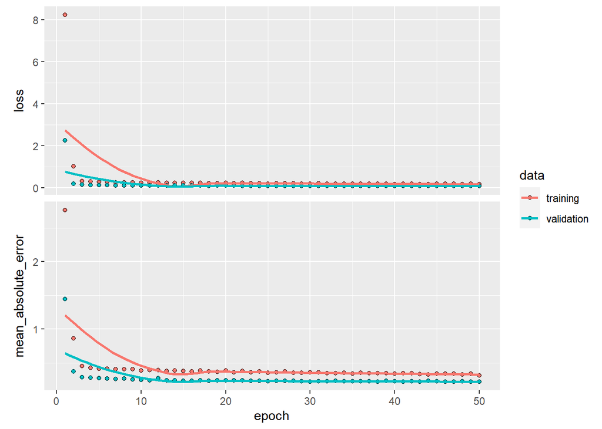

```r
plot(history_ann)
```

After tuning the model, we can now use it to predict **out-of-sample** data and test its accuracy.

```r
# Predicting using out-of-sample data
pred_test <- model_keras %>%
  predict(as.matrix(x_test_ann), batch_size = 50)

# Computing the RMSE for out-of-sample predictions
RMSE(pred_test, y_test_vector)
```

```
## [1] 0.2767014
```

After tuning our Artificial Neural Network, we came up with our final architecture and set of hyper parameters. The final Neural Networks has **3** hidden layers and *one* output layer. The *first* and *third* layer of neurons contain **32** neurons, whereas the second layer contains **64** neurons. The activation function chosen for both the first and the last neurons is the **relu** function: especially in the last layer, we want to keep an activation function with a *non-vanishing gradient*: an activation function that does not entail loss of information about the *input signal* due to its gradient-vanishing shape. In addition, we decided to set a dropout percentage of **30%** in order to reduce overfitting as much as we could (in fact, 30% is pretty high as a dropout percentage). **Three** dropout layers have been placed after each hidden layer of the neural network. In the end, we decided to set the optimizer as the **Moving** **average of the square of gradients** (set by the function *optimizer_rmsprop()*), a loss function as the mean squared error and a measure of accuracy as the mean absolute error: the **mean squared error** is one of the functions that performs most accurately with regression models.

In conclusion, we trained the model setting a *batch size* of **50** (number of observations coming through the network at each epoch) and **50** *epochs* (number of iterations of the batch through the model). Furthermore, we set the percentage of observations left for *validation* at **30%**, in order to avoid overfitting as much as possible.

```r
# Tuning Linear Regression Model
ln_regression <- lm(avg_rating ~ ., data=data_svm_train2)

# Calculating out-of-sample predictions for the Linear Model
lm_prediction <- predict(ln_regression, data_svm_test2)

# Calculating out-of-sample RMSE for Linear Regression
RMSE(lm_prediction, data_svm_test2$avg_rating)
```

```
## [1] 0.2383679
```